# Лабораторная работа № 6.

Серегин Д.А.

Российский университет дружбы народов, Москва, Россия

14 октября 2023

# Цель работы

Развить навыки администрирования ОС Linux. Получить первое практическое знакомство с технологией SELinux. Проверить работу SELinx на практике совместно с веб-сервером Apache.

# Выполнение работы

## Подготовка виртуальной машины

Перед выполнением лабораторной работы я подготовил виртуальную машину в соответствии с указаниями к лабораторной работе

## Выполнение работы

1. Вошел в систему с полученными учётными данными и убедился, что SELinux работает в режиме enforcing политики targeted.

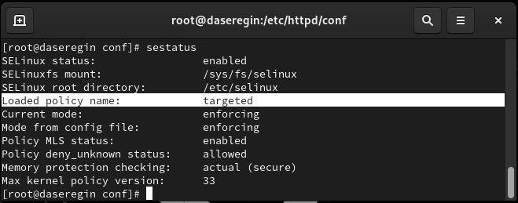

   Режим и политика SELinux

## Выполнение работы

2. Проверил работу веб-сервера с помощью браузера, убедившись, что он успешно работает.

[figure not shown]

   Стандартная страница Apache

## Выполнение работы

3. Нашел процесс веб-сервера Apache в списке процессов.

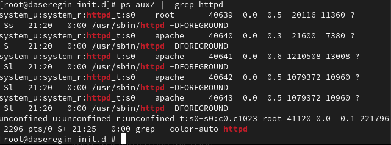

   Процесс веб-сервера Apache

## Выполнение работы

4. Проверил текущее состояние переключателей SELinux для Apache с использованием команды `sestatus -bigrep httpd`.

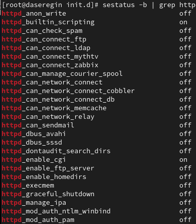

   Состояния переключателей Apache

## Выполнение работы

5. Получил статистику по политике с помощью команды `seinfo` и определил множество пользователей, ролей и типов.

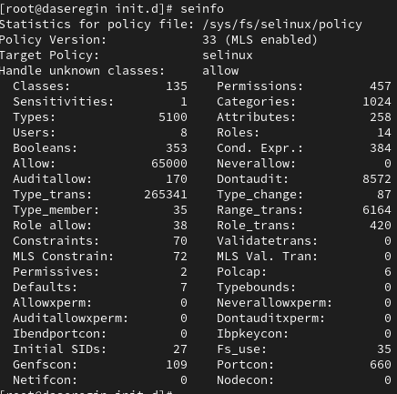

   Статистика по политику безопастности Apache

## Выполнение работы

6. Определил тип файлов и поддиректорий в директории `/var/www` с помощью команды `ls -lZ /var/www`.

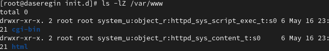

   Типы файлов

7. Определил тип файлов в директории `/var/www/html` с помощью команды `ls -lZ /var/www/html`. Как видим папка пуста.

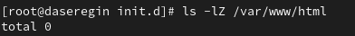

   Типы файлов

8. Определил круг пользователей, которым разрешено создание файлов в директории `/var/www/html`.

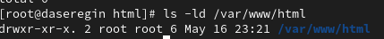

## Выполнение работы

9. Создал от имени суперпользователя файл `/var/www/html/test.html` с указанным содержанием.

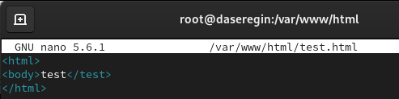

   Файл test.html

10. Проверил контекст созданного файла, внес контекст, присваиваемый по умолчанию новым файлам в директории `/var/www/html`

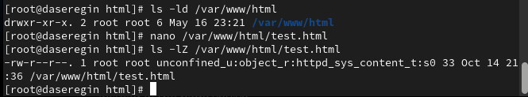

    Контекст файла

## Выполнение работы

11. Обратился к файлу через веб-сервер, введя в браузере соответствующий адрес, и убедился, что файл был успешно отображён.

[figure not shown]

    Отображение файла

12. Изучил справку `man httpd_selinux` и сопоставил контексты файлов для `httpd`. Проверил контекст файла с помощью команды `ls -Z /var/www/html/test.html`.

## Выполнение работы

13. Изменил контекст файла `/var/www/html/test.html` на другой, к которому процессу httpd не должен иметь доступа, и проверил изменение контекста.
14. Попытался снова получить доступ к файлу через веб-сервер и убедился, что была выдана ошибка “Forbidden”.

[figure not shown]

    Ошибка доступа

## Выполнение работы

15. Проанализировал ситуацию и выяснил, что файл не был отображен, несмотря на права доступа, изучив логи веб-сервера и системные логи.

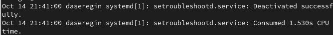

## Выполнение работы

[figure not shown]

    Ошибка соединения с сервером

## Выполнение работы

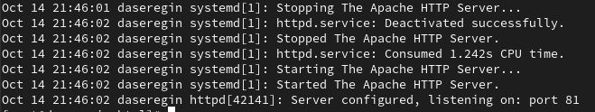

    Логи Apache

18. Проанализировал логи веб-сервера Apache и системные логи, определив, где появились новые записи.

## Выполнение работы

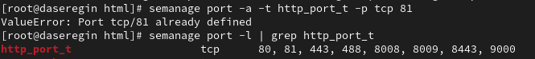

    Добавления порта 81 в разрешенные

20. Попытался снова запустить веб-сервер Apache и убедился, что он запустился успешно.

## Возвращение в исходное состояние

21. Вернул контекст файла `/var/www/html/test.html` к исходному, предварительно изменив его на `samba_share_t`.
22. Изменил обратно конфигурационный файл Apache, вернув порт прослушивания к 80.
23. Удалил привязку http_port_t к порту 81.
24. Удалил файл `/var/www/html/test.html`.

# Вывод

В результате выполнения работы я развил свои навыки администрирования Linux, смог настроить SELinux, а также поработать с веб-сервисом Apache.